# Ejercicios de estadistica basica

Ivan downham Vital

19/9/2020

## 1

¿Algunos poblados son más ventosos que otros? ¿Chicago merece el apodo de “la Ciudad de los vientos”? A cominuacrón aparece el promedio de velocidades del viento (en millas por hora) para 45 ciudades seleccionadas de Estados Unidos:

8.9 12.4 8.6 11.3 9.2 8.8 35.1 6.2 7.0 7.1 11.8 10.7 7.6 9.1 9.2 8.2 9.0 8.7 9.1 10.9 10.3 9.6 7.8 11.5 9.3 7.9 8.8 8.8 12.7 8.4 7.8 5.7 10.5 10.5 9.6 8.9 10.2 10.3 7.7 10.6 8.3 8.8 9.5 8.8 9.4

### a) Construya un histograma de frecuencia relativa para estos datos. (Seleccione las fronteras de clase sin incluir el valor de 35.1 en el intervalo de valores.)

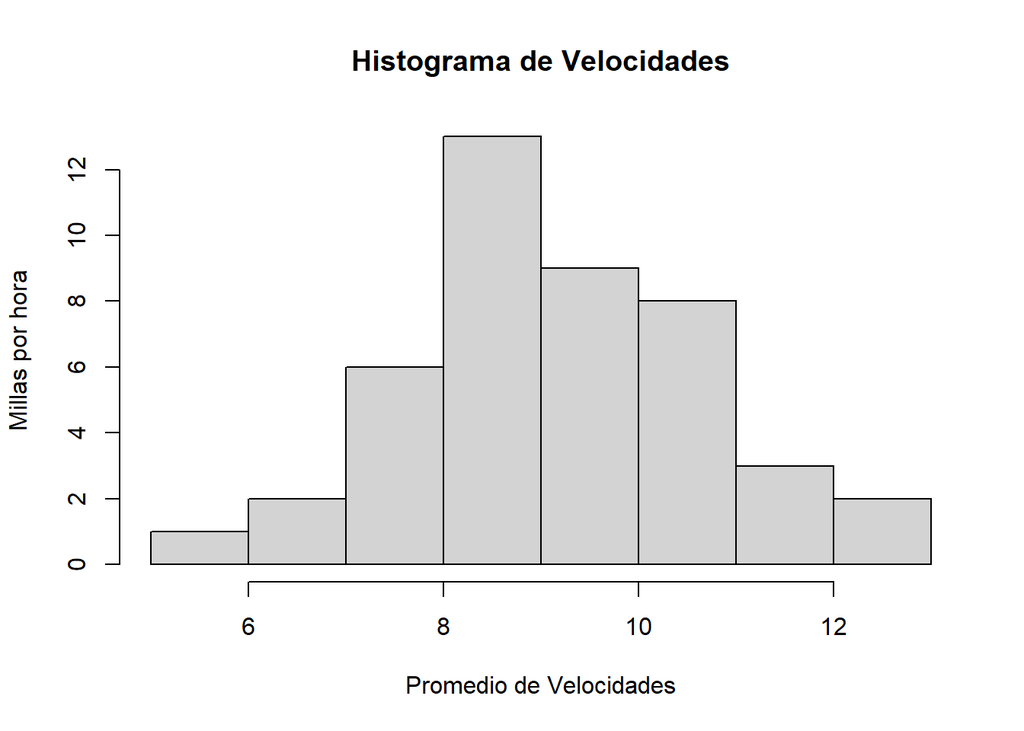

### b) El valor 35.1 se registró en Mt. Washington. New Hampshire. ¿La gcograffa de esa ciudad explica lamagnitud promedio de la velocidad de sus vientos?

El lugar de donde se sacó este promedio es Mt. Washington. New Hampshire, más conocido como el monte Washington. A continuación presento un fracmento de su descripción en Wikipedia:

“El monte Washington es el pico más alto del Noreste de Estados Unidos con 1917 m y la montaña más prominente al este del río Misisipi. Es famoso por su tiempo peligrosamente errático”

Es claro que este lugar presenta un clima que no corresponde a un estandar que se pueda comparar con lugares más bien comunes.

### c) El promedio de velocidad de vientos en Chicago es 10.3 millas por hora. ¿Qué porcentaje ele las ciudades tienen promedios de velocidad de vientos mayores que Chicago?

La proporción es, simplemente, la cantidad de ciudades que cumplen con la característica entre el total de ciudades.

```
## [1] 0.2444444
```

### d)¿Piensa usted que Chicago tiene vientos inusuales?

En paticular, no tiene vientos demasido exagerados, sin embargo, la proporción de ciudades que tienen vientos superiores es poca, además tomando en cuenta que uno de estos promedios es una zona con condiciones extremadamente erraticas en cuanto a su clima. Así que sí, los vientos de Chicago son poco usuales.

## 2

De gran importancia para residentes de la región central de Florida es la cantidad de material radiactivo presente en el suelo de zonas recuperadas de la explotación minera de fosfatos. Las mediciones de la cantidad de U-238 en 25 muestras de suelo fueron como sigue (mediciones en picocurios por gramo):

0.74 6.47 1.90 2.69 0.75 0.32 9.99 1.77 2.41 1.96 1.66 0.70 2.42 0.54 3.36 3.59 0.37 1.09 8.32 4.06 4.55 0.76 2.03 5.70 12.48

### Construya un histograma de frecuencia relativa para estos datos.

```
##    Class limits  f   rf rf(%) cf cf(%)
##  [0.3168,2.365) 13 0.52    52 13    52
##   [2.365,4.413)  6 0.24    24 19    76
##   [4.413,6.461)  2 0.08     8 21    84
##   [6.461,8.509)  2 0.08     8 23    92
##   [8.509,10.56)  1 0.04     4 24    96
##    [10.56,12.6)  1 0.04     4 25   100
```

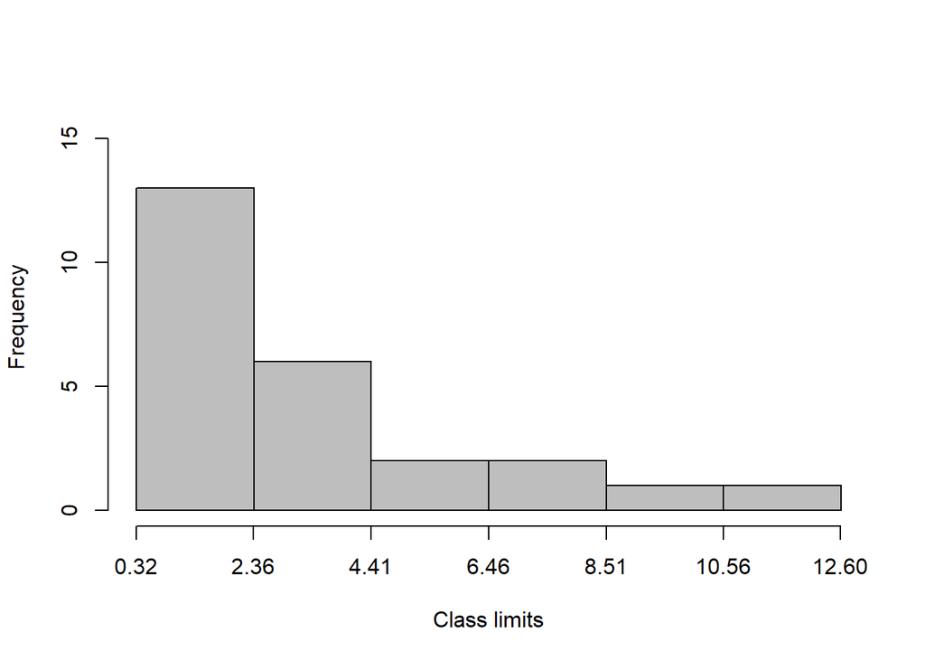

## 3

Las 40 acciones principales del mercado secundario (OTC, por sus siglas en inglés), clasificadas por el porcentaje de acciones en circulación vendidas en un día el año pasado son como sig ue:

11.88 6.27 5.49 4.81 4.40 3.78 3.44 3.11 2.88 2.68 7.99 6.07 5.26 -1.79 4.05 3.69 3.36 3.03 2.74 2.63 7.15 5.98 5.07 4.55 3.94 3.62 3.26 2.99 2.74 2.62 7.13 5.91 4.94 4.4 3.93 3.48 3.20 2.89 2.69 2.61

### a)Construya un histograma de frecuencia relativa para describir estos datos.

```
##  Class limits  f   rf rf(%) cf cf(%)
##   [-1.8,0.16)  1 0.03   2.5  1   2.5
##    [0.16,2.1)  0 0.00   0.0  1   2.5
##     [2.1,4.1) 23 0.58  57.5 24  60.0
##     [4.1,6.1) 11 0.28  27.5 35  87.5
##     [6.1,8.1)  4 0.10  10.0 39  97.5
##      [8.1,10)  0 0.00   0.0 39  97.5
##       [10,12)  1 0.03   2.5 40 100.0
```

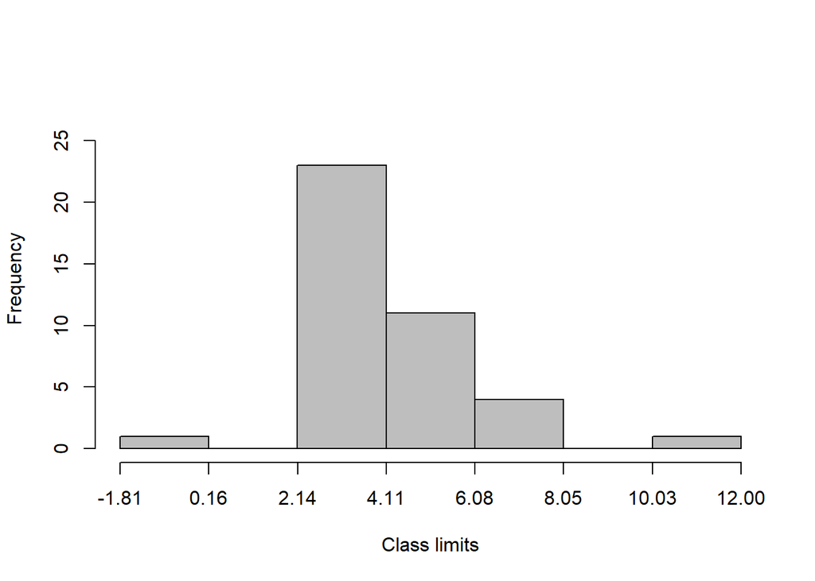

### b) ¿Qué proporción de estas 40 acciones principales vendió más de 4% de las acciones en circulación?

```
## [1] 0.425
```

### c) Si una de las acciones se selecciona al azar de las 40 para las que se tomaron los datos precedentes.¿cuál es la probabilidad de que venda menos de 5% de sus a cciones en circulación?

Es claro que $P(X<5)=\frac{\#(X<5)}{\#(X)}$, es decir que $P(X<5)$ es:

```
## [1] 0.725
```

## 4

Aquí damos el histo grama de frecuencia relativa asociado con los promedios de puntos de calificación (PPC) de una muestra de 30 estudiant es:

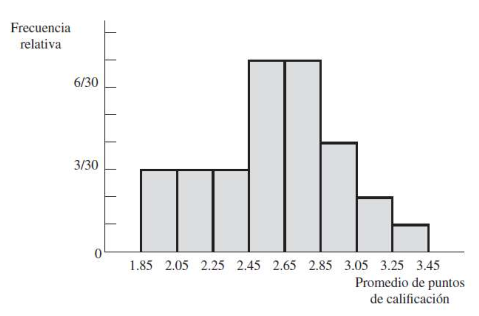

Grafica Ejercicio 4

### a) ¿Cuáles de las categorías de PPC identificadas en el eje hori zontal están asocia das con la proporción más grande de estudiantes?

Las categorías con la proporción más grande son las correspondientes a los intervalos (2.45, 2.65) y (2.65, 2.85)

### b) ¿Qué proporción de estudiantes tuvo PPC en cada una de las categorías que identificamos?

Primero debemos identificar las proporciones por intervalo, a cada intervalo lo llamaremos $s_i$ para $i=1,2,...,8$

Ahora sólo debemos multiplicar cada uno de los $s_i$ por el tamaño de la muestra

[output not shown]

### c ¿Qué proporción de los estudiantes tuvo PPC menores que 2.65?

En este caso, los 4 primeros intervalos son menores a 2.65, sólo debemos sumar los primeros $s_i$

```
## [1] 0.5
```

## 5

El histograma de frecuencia relativa que aparece acontinuación se construyó a partir de datos obtenidos de una muestra aleatoria de 25 familias. A cada una se le preguntó el número de cuartos de galón de leche que habían comprado la semana previa.

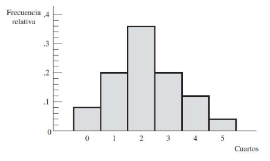

Grafica Ejercicio 5

### a) Use este histograma de frecuencia relativa para determinar el número de cuartos de leche comprados por la proporción más grande de las 25 familias. La categoría asociada con la frecuencia relativa más grande se denomina categoría modal

Es calro que la frecuencia modal es la asociada con el número 2 y corresponde al 36% de la población, al multiplicar 0.36 por 25, tenemos que 9 de las 25 familias compran 2 cuartos de leche.

## 6

Las estturas detectadas por 105 estudiantes de un grupo de bioestadística se emplearon para construír el histograma que aparece a continuación.

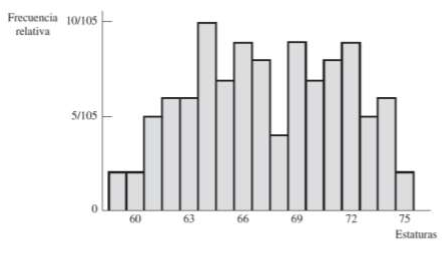

Grafica Ejercicio 6

### a) describa la forma del histograma

En general el histograma es errático, con saltos entre frecuencias altas con bajas. Sin embargo, es claro que en los puntos que corresponden a los valores al rededor de 60 y 75, el histograma decrece y que en los valores cerca de67 los valores del histograma llegan a sus valores más altos, aunque justo a la mitad haya un decaimiento, en promedio, los valores sobresalen más que los de las orillas. Todo esto nos da la idea de que esto puede referir a una población normal.

### b) ¿Este histograma tiene una caraterística poco común?

Efectivamente. Justo en sus valores medios rompe la tendencia de crecimiento que tiene cuando de las orillas se acercan al centro. En pocas palabras, el valore de la media, en realidad es poco común dentro de la misma población.

### c) ¿Puede el lector dar una explicación acerca de los dos picos en el histograma? ¿Hay alguna caracterización de la estatura que resulta en los dos picos separados? ¿Cuál es?

En realidadm estos dos picos podrían deberse a que la muestra no fue lo suficientemente grande o a que se tomó en lugares con una discrepancia muy alta en cuanto a sus estaturas.

Esta forma con dos picos podría verse en las horas que las personas laboran en el trabajo. Esto debido a que, en general, las personas sólo pueden trabajar ya sea en un turno o en medios turnos. Pocas personas trabajarían en rangos medios entre esas dos opciones.

### 7

Un artículo en Archaeometry presentó un análisis de 26 muestras de cerámica romano-británica hallada en cuatro hornos en sitios diferentes del Reino Unido. El porcentaje de óxido de aluminio en cada una de las 26 muestras aparece a continuación

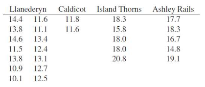

### a) Construya un histograma de frecuencia relativa para describir el contenido de óxido de aluminio de las 26 muestras de cerámica.

```
##     Class limits f   rf rf(%) cf  cf(%)
##   [9.999,11.834) 7 0.27 26.92  7  26.92
##  [11.834,13.669) 5 0.19 19.23 12  46.15
##  [13.669,15.503) 5 0.19 19.23 17  65.38
##  [15.503,17.338) 2 0.08  7.69 19  73.08
##  [17.338,19.173) 6 0.23 23.08 25  96.15
##  [19.173,21.008) 1 0.04  3.85 26 100.00
```

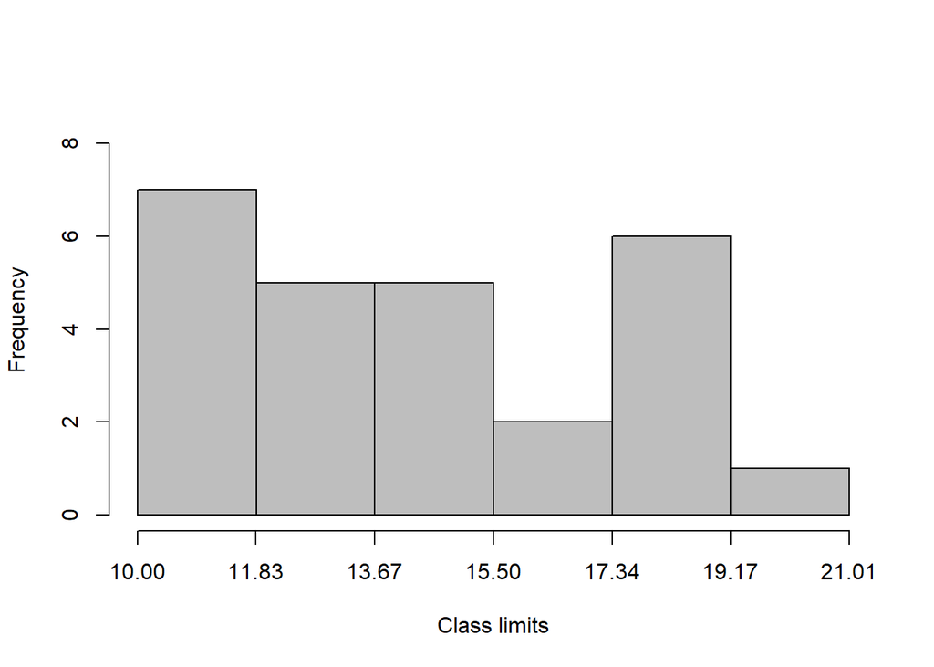

### b) ¿Qué característica poco común observa el lector en este histograma? Al ver los datos. ¿puede dar una explicación de esta característica poco común?

Este es un caso similar al anterior, aquí empezamos el histograma con valores altos que deacaen, sin embargo, luego vuleve a haber un realce en forma de pico que vuelve a decrecer.

## 9

Los ritmos de respiración en reposo para estudiantes en edad universitaria están normalmente distribuidos. en forma aproximada, con una media de 12 y desviación estándar de 2.3 respiraciones por minuto.¿Qué fracción de todos los estudiantes en edad universitaria tienen ritmos de respiración en los intervalos siguientes?

### a) 9.7 a 14.3 respiraciones por minuto

```
## [1] 0.6826895
```

### b) 7.4 a 16.6 respiraciones por minuto

```
## [1] 0.9544997
```

### c) 9.7 a 16.6 respiraciones por minuto

```
## [1] 0.8185946
```

### d) Menos de 5.1 o más de 18.9 respiraciones por minuto

```
## [1] 0.002699796
```

## 10

Se ha proyectado que el promedio y la desviación estándar del tiempo empleado en Línea usando la Internet son, respectivamente, 14 y 17 horas por persona por año (muchos no usan la Internet en absoluto).

### a) ¿Qué valor está exactamente a 1 desviación estándar debajo de la media?

Esto es simple, no nos pide probabilidades, sólo el valor que se encuentra a 17 unidades por debajo de 14, esto es -3.

### b) Si el tiempo empleado en línea usando la Internet está normalmente distribuido en forma aproximada, ¿qué proporción de los usuarios pasa un tiempo en línea que es menor al valor hallado en el inciso a?

[output not shown]

## 11

Los deportes acuáticos se han sugerido como método de ejercicio cardiovascular para atletas lesionados y otros que deseen un programa de entrenamiento aeróbico de bajo impacto. En un estudio para investigar la relación entre cadencia de ejercicios y ritmo cardiaco. Se midieron los ritmos cardiacos de 20 voluntarios en buenas condiciones a una cadencia de 48 ciclos por minuto (un ciclo formado por dos pasos). Los datos son como sigue:

87 109 79 80 96 95 90 92 96 98 101 91 78 112 94 98 94 107 81 96

### a) Use la amplitud de las mediciones para obtener una estimación de la desviación estándar.

En este caso, los valores que nos muestran podrían corresponder a una desviación estandar del 5.

### b) Construya un histograma de frecuencia para Jos datos. Use el histograma para obtener una aproximación visual a y-barra y s.

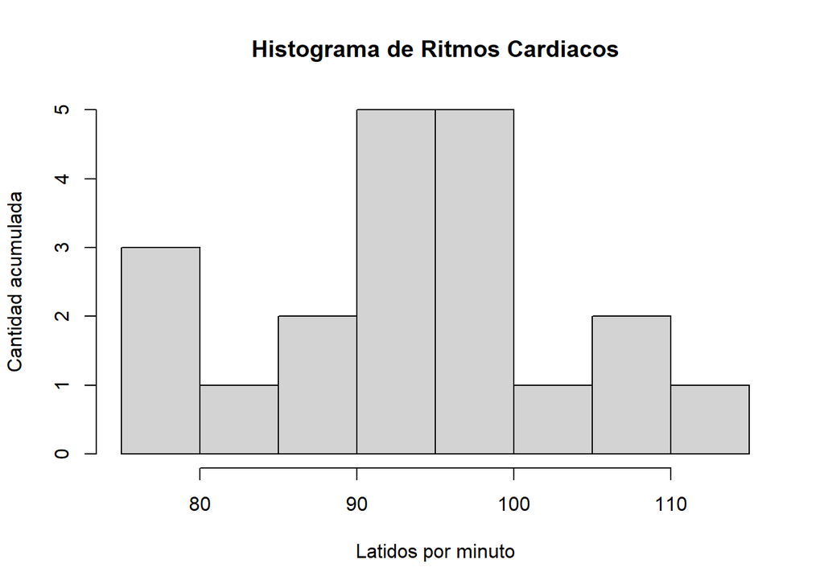

Parece que la media puede rondar entre los valores de 90 y 100, sin embargo, este valor puede no estar en ese rango debido al pico que se luce al principio del histograma. La desviación estandar parece estar rondando entre 5 y 10.

### c) Calcule y-barra y s. Compare estos resultados con las verificaciones de cálculo proporcionadas por los incisos a y b

```
## [1] 93.7
```

```
## [1] 9.553726
```

Efectivamente los valores salieron según lo esperado, auqnue la desviación estandar están en límite de lo que yo esperaba y la media un poco menor a lo que se podía ver en el hitograma, auqnue esperado por lo mencionado antes.

### d) Construya los intervalos y ± ks. k = 1, 2 y 3, y cuente el número de mediciones que caen en cada intervalo. Compare las fracciones que caen en los intervalos con las fracciones que esperaría de acuerdo con la regla empírica.

La cantidad de valores que caen dentro de los intervalos calculdos son

```
## [1] 13
```

```
## [1] 20
```

```
## [1] 20
```

Según la regla empirica, el 68% de los datos deben estar en el intervalo con 1 desviación estandar de amplitud, es decir, al redeor de 14, se acerca bastante al número de nuesttro intervalo. Para el intervalo de 2 desviaciones estandar de amplitud le corresponde el 95%, es decir 19, también se parece mucho auqnue a partir de aquí ya avarcó todos los datos, esto posiblemente sea por la cantidad tan reducida de los datos.

## 12

Los datos siguientes dan los tiempos de falla para n= 88 radiotransmisores-receptores:

16 224 16 80 96 536 400 80 392 576 128 56 656 224 40 32 358 384 256 246 328 464 448 716 304 16 72 8 80 72 56 608 108 194 136 224 80 16 424 264 156 216 168 184 552 72 184 240 438 120 308 32 272 152 328 480 60 208 340 104 72 168 40 152 360 232 40 112 112 288 168 352 56 72 64 40 184 264 96 224 168 168 114 280 152 208 160 176

### a) Utilice el rango para calcular s para los n = 88 tiempos para falla

```
## [1] 177
```

### b) Construya un histograma de frecuencia para los datos. [Observe la tendencia de la distribución a extenderse hacia fuera (sesgo) a la derecha.]

```
##      Class limits  f   rf rf(%) cf  cf(%)
##     [7.92,97.325) 27 0.31 30.68 27  30.68
##   [97.325,186.73) 22 0.25 25.00 49  55.68
##  [186.73,276.135) 15 0.17 17.05 64  72.73
##  [276.135,365.54) 10 0.11 11.36 74  84.09
##  [365.54,454.945)  6 0.07  6.82 80  90.91
##  [454.945,544.35)  3 0.03  3.41 83  94.32
##  [544.35,633.755)  3 0.03  3.41 86  97.73
##  [633.755,723.16)  2 0.02  2.27 88 100.00
```

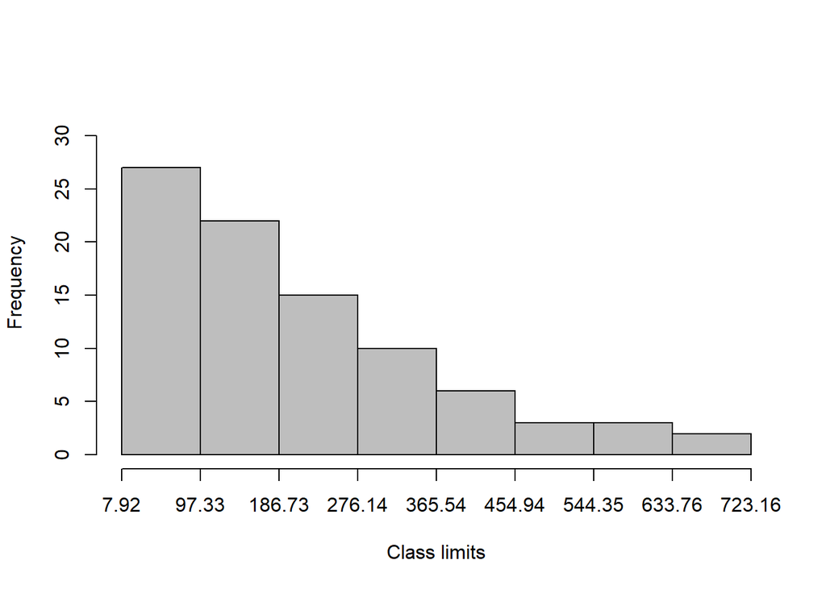

### c) Use una calculadora (o computadora) para calcular y y s. (Hacer manualmente el cálculo es demasiado tedioso para este ejercicio.)

```
## [1] 210.7955
```

```
## [1] 162.1728
```

### d) Calcule los intervalos y ± ks, k = 1, 2 y 3. y cuente el número de mecliciones que caen en cada intervalo. Compare sus resultados con los resultados de la regla empírica. Observe que la regla empírica proporciona una descripción más o menos buena de estos datos, aun cuando la distribución está altamente sesgada.

La cantidad de datos que están en estos intervalos son

```
## [1] 63
```

```
## [1] 82
```

```
## [1] 87
```

Bajo la regla emírica los la cantidad de datos que deberían de estas dentro de estos datos son, respectivamente 60, 84 y 88. Podemos ver que se aproxima bastante bien.

## 13

An a study of the oral home cure practico and rcusons for secking dental care among individuals on renal dialysis, Atassi (A~ l) studjcd 90 subjects on renal dialysis. The oral hygiene status of a11 subjects was examined using a plaque index with a range of O to 3 (O - no soft plaque deposiis, 3 = an abundance of soft plaque deposits). The following table shows the plaque index seores for all 90 subjects

1.17 2.50 2.00 2.33 1.67 1.33 1.17 2.17 2.17 1.33 2.17 2.00

### a) Use these data to prepare:

A Frequency distribution A relative frequency distribution A cumuJative frequency distribution A cumuJative relative frequency distribution A histogram A frequency poJygon

```
##   Class limits f   rf rf(%) cf  cf(%)
##  [1.158,1.432) 4 0.33 33.33  4  33.33
##  [1.432,1.705) 1 0.08  8.33  5  41.67
##  [1.705,1.978) 0 0.00  0.00  5  41.67
##  [1.978,2.252) 5 0.42 41.67 10  83.33
##  [2.252,2.525) 2 0.17 16.67 12 100.00
```

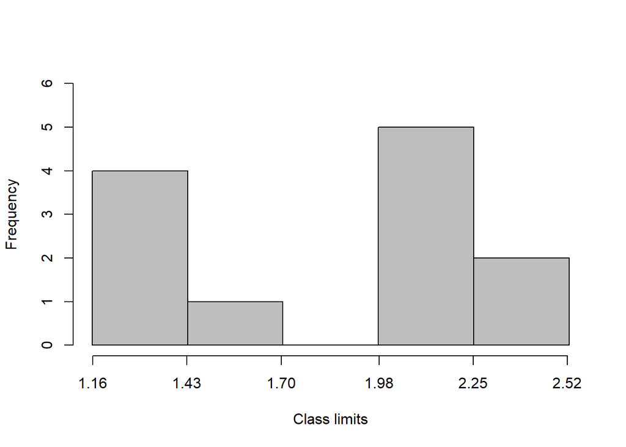

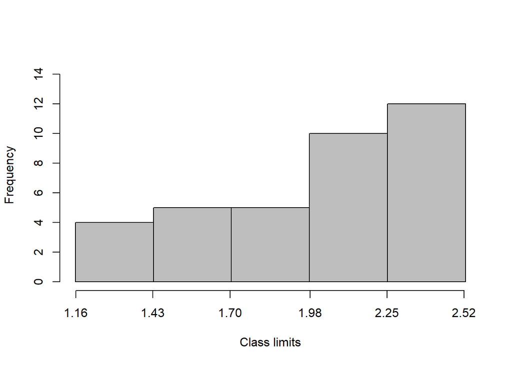

### b) What percentage of the measurernents are less than 2.00?

[output not shown]

### c) What proportion of the subjects bave measurements greater than or equal to 1.50?

[output not shown]

### d) What percentage of the measurements are between 1.50 and 1.99 inclusive?

[output not shown]

### e) How many of the measurements are greater than 2.49?

[output not shown]

### f) What proportion of the measurements are either less than 1.0 or greater lhan 2.49?

[output not shown]

## 14

Janardhan et aJ. (A-2) conducted a study in which they measured incidental intracranial aneurysms (IIAs) in 125 patients. Toe researchers exarnined postproceduraJ complications and concluded that IIAs can be safely treated without causing mortaJity and with a Jower cornplications rate than previously reponed. The following are the sizes (in millirneters) of the 159 IIAs in the sarnple.

8.1 10.0 5.0 7.0 10.0 3.0 20.0 4.0 4.0 6.0 6.0 7.0

### a) Use these data to prepare:

A Irequency distribution A relative Irequency distribution A cumulative frequency distribution A cumulative relative frequency distribution A histogram A Irequency polygon

```
##   Class limits f   rf rf(%) cf  cf(%)
##   [2.97,6.416) 6 0.50 50.00  6  50.00
##  [6.416,9.862) 3 0.25 25.00  9  75.00
##  [9.862,13.31) 2 0.17 16.67 11  91.67
##  [13.31,16.75) 0 0.00  0.00 11  91.67
##   [16.75,20.2) 1 0.08  8.33 12 100.00
```

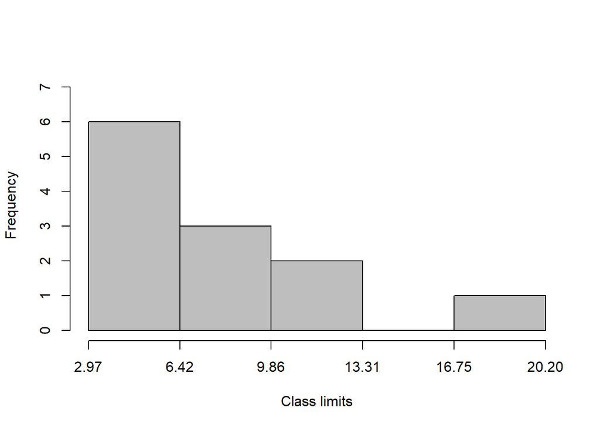

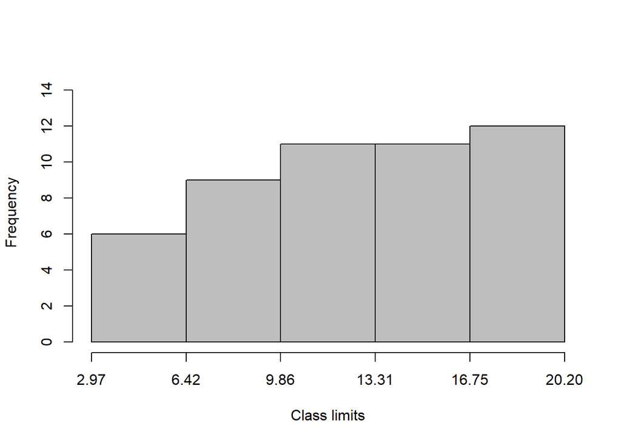

### b) What percentage of the rneasurernents are between 10 and 14.9 inclusive?

```
## [1] 0.1666667
```

### c) How many observations are less than 20?

```
## [1] 11
```

### d) What proportion of the measurements are greater than or equal to 25?

```
## [1] 0
```

### e) What percentage of the measurements are either less than 10.0 or greater than 19.95?

```
## [1] 0.8333333
```

## 15

Hoekerna et al (A-3) studied the craniofacial morpbology of patients diagnosed with obstructive sleep apnea syndrome (OSAS) in healthy male subjects. One of the demographi variables the researchers collected for all subjects was the Body Mass Index (calculated by dividing weight in kg by tbe squa.re of tbe patient’s heigbt in cm). Toe following are tbe BMI vaJues of 29 OSAS subjects.

33.57 27.78 40.81

### a) Use these data to construct:

A frequency distribution A relalive frequency distribution A cumulalive frequency distribut ion A cumulative relative Irequency distribution A histogram A frequency polygon

```
##     Class limits f   rf rf(%) cf  cf(%)
##  [27.502,32.074) 1 0.33 33.33  1  33.33
##  [32.074,36.646) 1 0.33 33.33  2  66.67
##  [36.646,41.218) 1 0.33 33.33  3 100.00
```

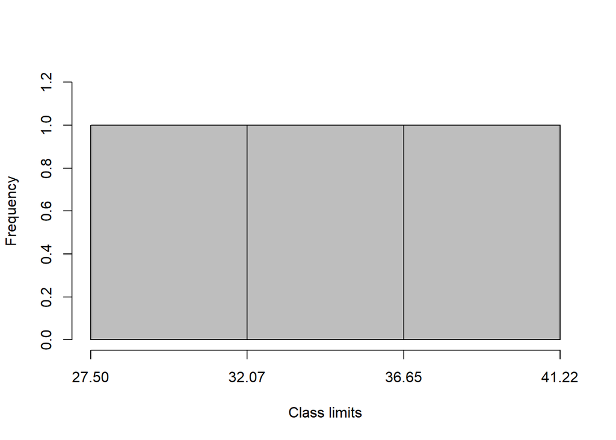

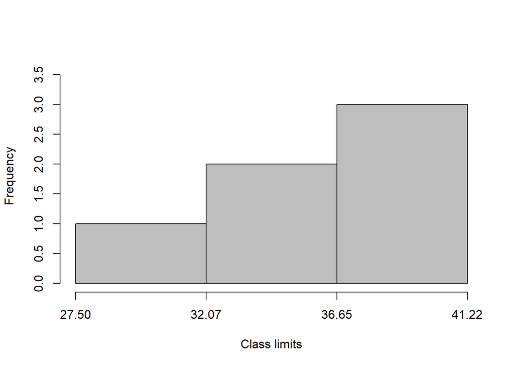

### b) What percentage of lbe measurernents are less than 30?

Debido a que sólo hay un dato con valor menor a 30, la proporción de los menores es de $\frac{1}{3}$

### c) What percentage of the measurernents are between 40.0 and 49.99 inclusive?

Como sólo hay un dato que cumple con esta característica, el procentaje de es 33.33%

## 16

David Holben (A-4) studi.cd selenium levels in becf raiscd in a low seleniwn región of che Unitcd States. The goal of the study was to compare selenium lcvels in thc region-raiscd beef to seleniurn levels in cooked venison. squirrel. and beef frorn othcr regions of the Unitcd Statcs. Thc data below are the selenium lcvels calculated on a dry wcigbt basis in u,g/ 100 g for a sample of 53 region-raiscd cattle.

11.23 15.82

### a) Use thesc data to construct:

A frequency distribution A relative frcqucncy distribution A cumulativc frequency distribution A cumulative relative frcquency distribution A bistogram A frequency polygon

```
##     Class limits f  rf rf(%) cf cf(%)
##  [11.118,13.548) 1 0.5    50  1    50
##  [13.548,15.978) 1 0.5    50  2   100
```

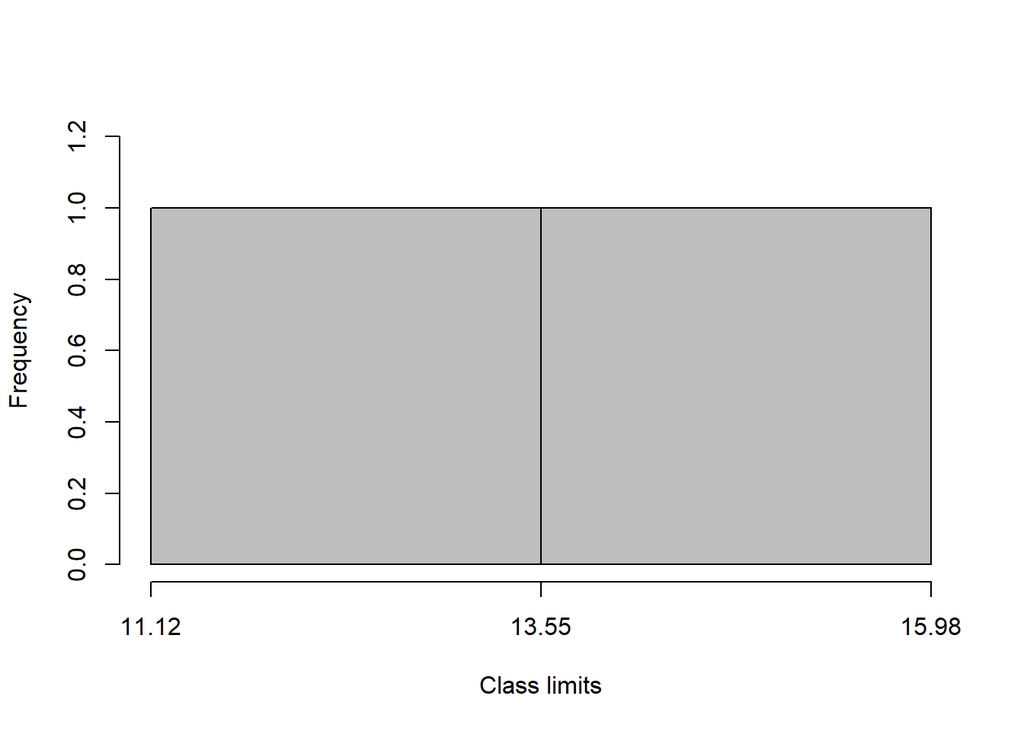

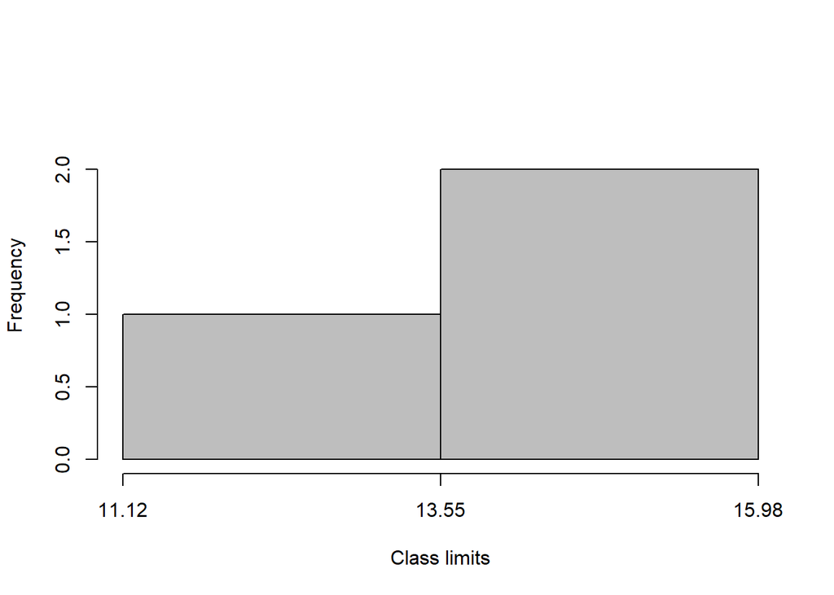

### b) Obtener Skewness

```
## [1] 0
```

## 17

Thc following table shows tbe number of hours 45 hospital paticnts slept foUowing thc administration of a certain anesthetic.

7 10 12 4 8 7 3 8 5 12 11 3 8 1 1 13 10 4 4 5 5 8 7 7 3 2 3 8 13 1 7 17 3 4 5 5 3 1 17 10 4 7 7 11 8

### a) From these data construct:

A frequency distribution A relative frequency distribution A histograrn A frequcncy polygon

```
##     Class limits  f   rf rf(%) cf  cf(%)
##    [0.99,3.3014) 11 0.24 24.44 11  24.44
##  [3.3014,5.6129) 10 0.22 22.22 21  46.67
##  [5.6129,7.9243)  7 0.16 15.56 28  62.22
##  [7.9243,10.236)  9 0.20 20.00 37  82.22
##  [10.236,12.547)  4 0.09  8.89 41  91.11
##  [12.547,14.859)  2 0.04  4.44 43  95.56
##   [14.859,17.17)  2 0.04  4.44 45 100.00
```

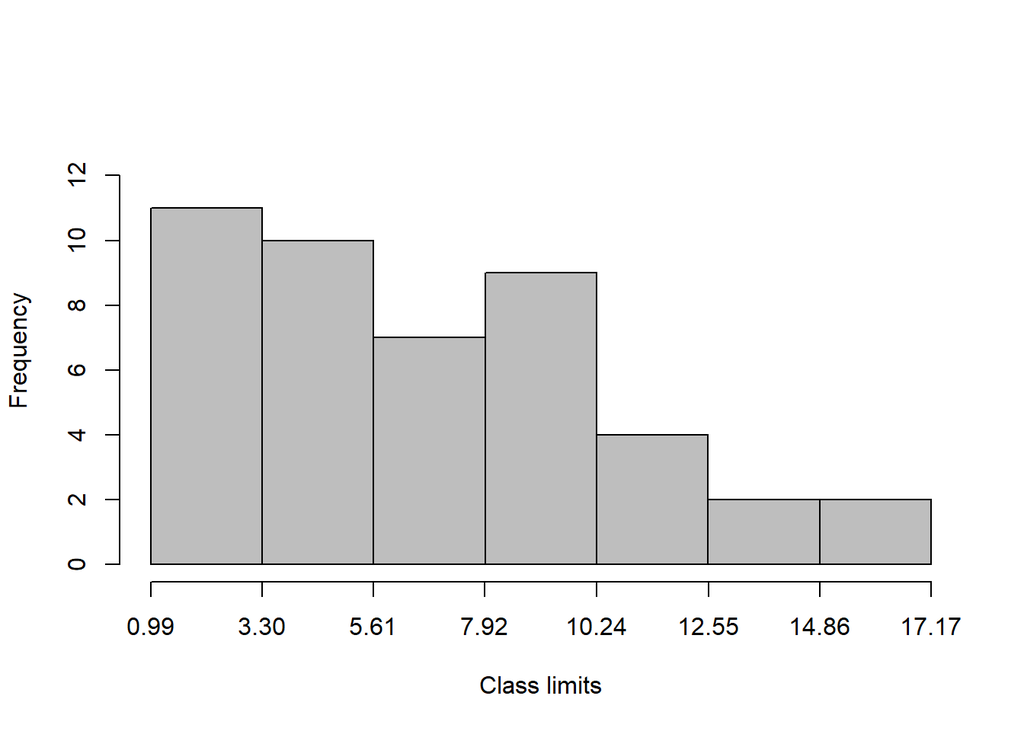

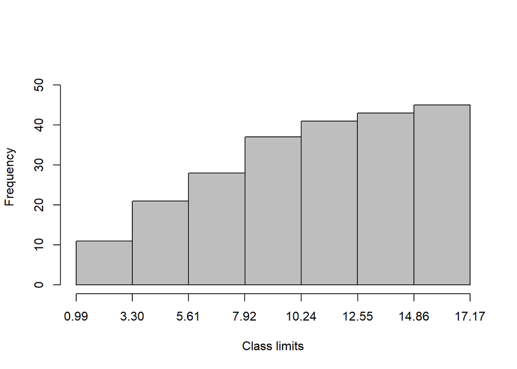

### b) Obtener Skewness

```
## [1] 0.6931457
```

## 18

The following are the number of bables born during a year in 60 community hospitals.

30 55 27 45 56 48 45 49 32 57 47 56 37 55 52 34 54 42 32 59 35 46 24 57 32 26 40 28 53 54 29 42 42 54 53 59 39 56 59 58 49 53 30 53 21 34 28 50 52 57 43 46 54 31 22 31 24 24 57 29

### a) From thesc data construct:

A frequency distribution A relative frequcncy distribution A histogram A frequency polygon

```
##     Class limits  f   rf rf(%) cf  cf(%)
##   [20.79,26.333)  6 0.10 10.00  6  10.00
##  [26.333,31.876)  9 0.15 15.00 15  25.00
##  [31.876,37.419)  7 0.12 11.67 22  36.67
##  [37.419,42.961)  5 0.08  8.33 27  45.00
##  [42.961,48.504)  7 0.12 11.67 34  56.67
##  [48.504,54.047) 13 0.22 21.67 47  78.33
##   [54.047,59.59) 13 0.22 21.67 60 100.00
```

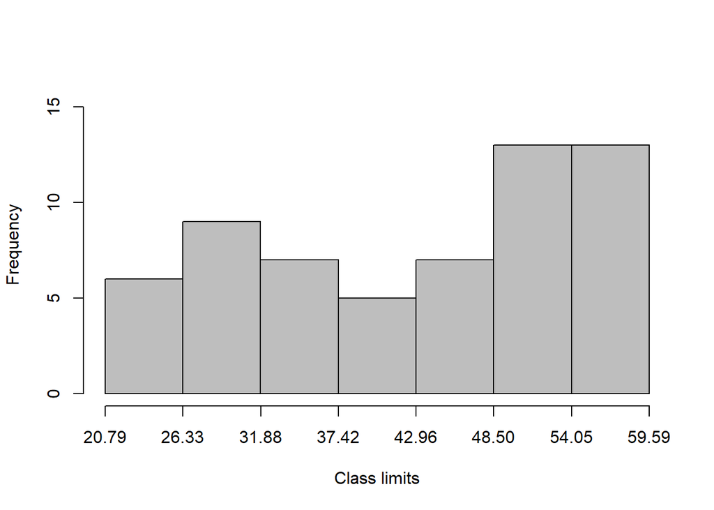

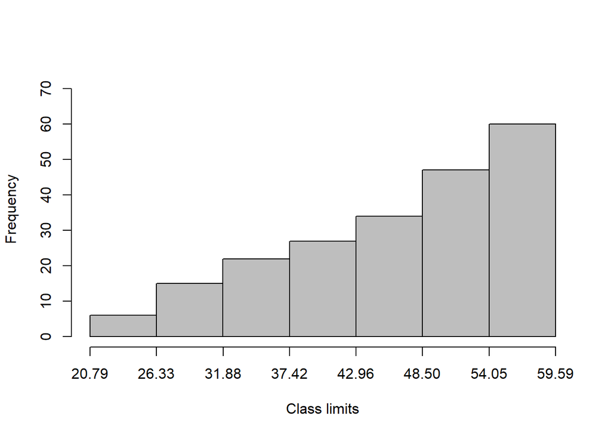

### b) Obtener Skewness

```
## [1] -0.2965981
```

## 19

In a study of physical endurance levels of male collcge freshman, the following composite endurance seores based on severa excrcise routines were collcctcd.

254 281 192 260 212 179 225 179 181 149

### a) From thcsc data construct:

A frequcncy distribution A rclative frequency distribution A frequency polygon A histogram

```
##     Class limits f  rf rf(%) cf cf(%)
##  [147.51,174.77) 1 0.1    10  1    10
##  [174.77,202.03) 4 0.4    40  5    50
##  [202.03,229.29) 2 0.2    20  7    70
##  [229.29,256.55) 1 0.1    10  8    80
##  [256.55,283.81) 2 0.2    20 10   100
```

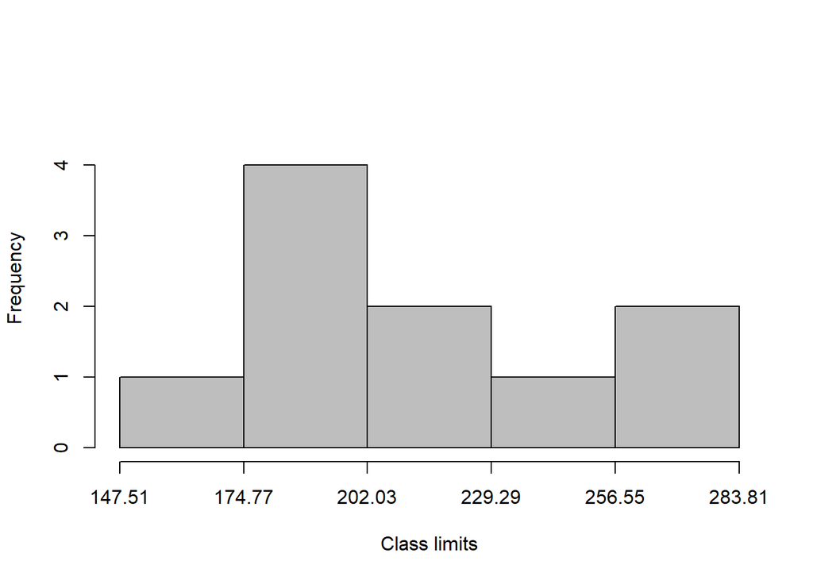

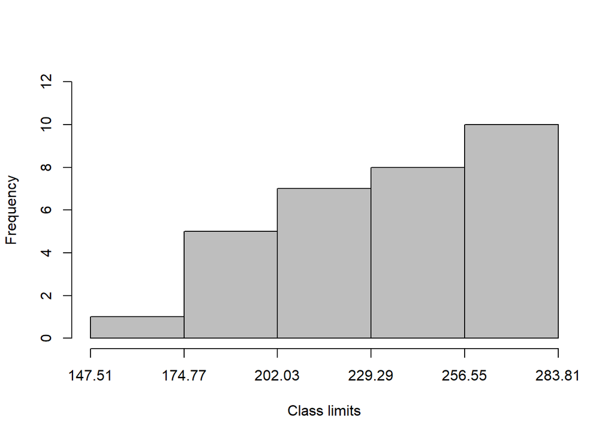

### b) Obtener Skewness

```
## [1] 0.2913691
```

## 20

Schmidt et al. (A·6) conducted a study to investigare whether autotransfusion of shed mediastinal blood could reduce the number of patients needing homologous blood transfusión and reduce the amount of transfused homologous blood if fixed transfusión criteria wcre used. The following table shows the heights in centimeters of the 109 subjects of whom 97 were males.

1.720 1.710 1.700 1.655 1.800 1.700 1.730 1.700 1.820 1.810 1.720 1.800

### a) For these data construct the following distributions: frequency, relative frequency. cumulativc frequency. and cumulative relativo frequency; aud the following graphs: h.istogram. frequcncy polygon. and stern-and-lcaf plot.

```
##   Class limits f   rf rf(%) cf  cf(%)
##  [1.638,1.678) 1 0.08  8.33  1   8.33
##  [1.678,1.718) 4 0.33 33.33  5  41.67
##  [1.718,1.758) 3 0.25 25.00  8  66.67
##  [1.758,1.798) 0 0.00  0.00  8  66.67
##  [1.798,1.838) 4 0.33 33.33 12 100.00
```

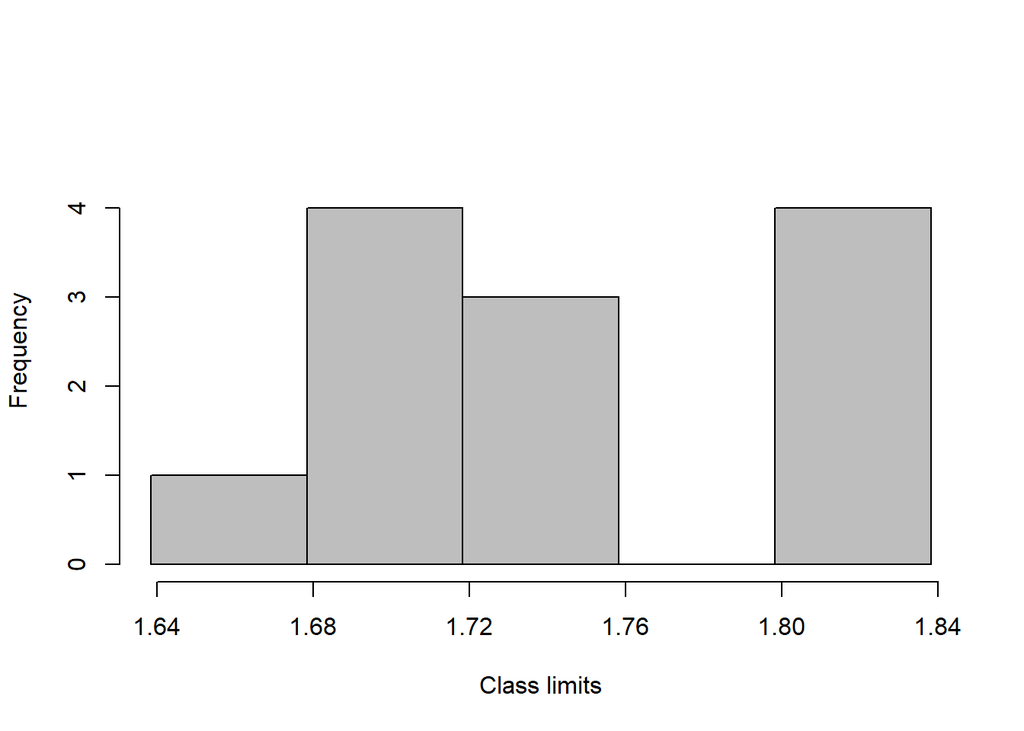

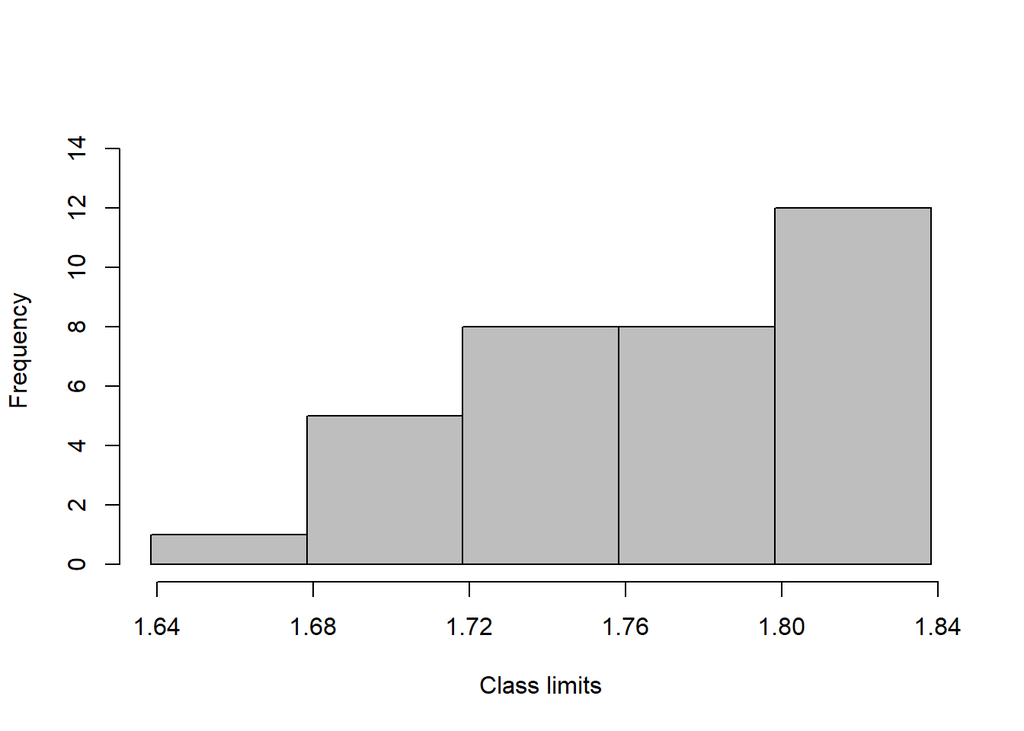

```
##
##   The decimal point is 1 digit(s) to the left of the |
##
##   16 | 6
##   17 | 0001223
##   17 |
##   18 | 0012
```

### b) Obtener Skewness

```
## [1] 0.3329136
```

### c) How do you account for the shape of the distribution of these data?

Podríamos pensar que existen dos tipos de datos que están interviniendo en la muestra, es decir que las concentraciones se dividen en dos centros debino a que hay dos poblaciones más probables interviviendo.

### d) How tall were the tallcst 6.42 percent of tbe subjects?

```
##   93.58%
## 1.812938
```

### c) How tall were the shortest 10.09 percent of the subjects?

```
## 10.09%
##    1.7
```